# Homework 2

Joe Dickerson

2025-01-30

```r
## Packages
library(faraway)
library(tidyverse)
data(seeds)
```

1. It appears that when the container is not covered, we see germination increase as moisture increases. With a cover, we see higher germination at the lower moisture levels, and lower germination at the higher moisture levels. It appears that the cover helped to create an ideal environment for the seeds at lower moisture levels than when the seeds are uncovered.

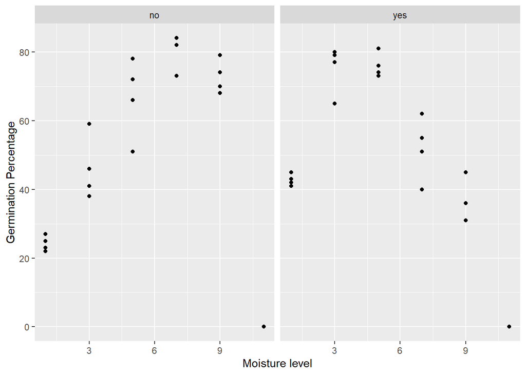

```r
seeds %>%
  ggplot(aes(y = germ, x = moisture)) +
  geom_point() +
  facet_grid( ~ covered) +
  labs(x = "Moisture level", y = "Germination Percentage")
```

2. There does not appear to be a box effect based on the plot.

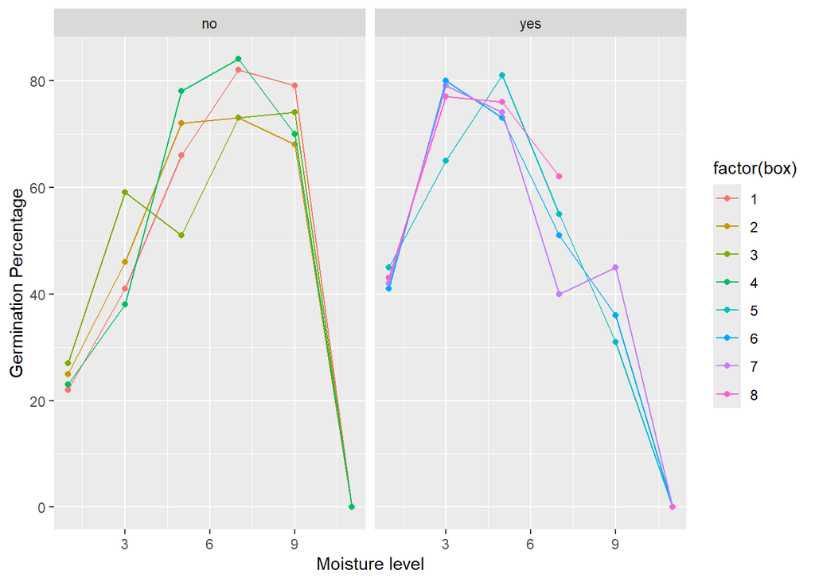

```r
df <- seeds %>%
  mutate(box = rep(1:8, each = 6))

df %>% ggplot(aes(y = germ, x = moisture, color = factor(box))) +
  geom_point() +
  geom_line() +
  facet_grid( ~ covered) +
  labs(x = "Moisture level", y = "Germination Percentage")
```

3. It seems that box has no effect on the model and can be excluded.

```r
glmod <- glm(cbind(germ, 100 - germ) ~ moisture + covered + factor(box), family = binomial, df)

summary(glmod)
```

```
##
## Call:
## glm(formula = cbind(germ, 100 - germ) ~ moisture + covered +
##     factor(box), family = binomial, data = df)
##
## Coefficients: (1 not defined because of singularities)
##               Estimate Std. Error z value Pr(>|z|)
## (Intercept)   0.593872   0.098319   6.040 1.54e-09 ***
## moisture     -0.110487   0.008813 -12.537  < 2e-16 ***
## coveredyes    0.067297   0.123410   0.545    0.586
## factor(box)2 -0.041493   0.117609  -0.353    0.724
## factor(box)3 -0.041493   0.117609  -0.353    0.724
## factor(box)4  0.020724   0.117544   0.176    0.860
## factor(box)5 -0.157309   0.123521  -1.274    0.203
## factor(box)6 -0.129567   0.123476  -1.049    0.294
## factor(box)7 -0.136498   0.123486  -1.105    0.269
## factor(box)8        NA         NA      NA       NA
## ---
## Signif. codes:  0 '***' 0.001 '**' 0.01 '*' 0.05 '.' 0.1 ' ' 1
##
## (Dispersion parameter for binomial family taken to be 1)
##
##     Null deviance: 1791.0  on 46  degrees of freedom
## Residual deviance: 1624.4  on 38  degrees of freedom
##   (1 observation deleted due to missingness)
## AIC: 1832.1
##
## Number of Fisher Scoring iterations: 5
```

```r
glmod_sum = summary(glmod)
```

4. We have very low p-values, which would indicate problems with the model. Performing a chi-sq test on both the model with and without box confirms the absence of the box predictor is a better choice of model.

```r
## model without box

glmod2 <- glm(cbind(germ, 100-germ) ~ moisture + covered, family = binomial, df)
glmod2_sum = summary(glmod2)

pchisq(deviance(glmod2), df.residual(glmod2), lower = F)
```

```
## [1] 1.48907e-312
```

```r
pearsonstat = sum(residuals(glmod, "pearson")^2)
pearsonstat2 = sum(residuals(glmod2, "pearson")^2)

pchisq(pearsonstat, glmod_sum$df.residual, lower.tail = F)
```

```
## [1] 3.095181e-260
```

```r
pchisq(pearsonstat2, glmod2_sum$df.residual, lower.tail = F)
```

```
## [1] 3.310894e-256
```

5. According to this prediction, it appears that moisture 1 is the predicted moisture for maximum germination in both covered and uncovered boxes. However, this seems to contradict the plots, so I’m not confident in the accuracy of this result.

```r
seeds <- na.omit(seeds)

glmod2pred <- predict(glmod2, type = "link")

seeds$pred <- glmod2pred

nocover <- seeds[seeds$covered == "no",]
covered <- seeds[seeds$covered == "yes",]

which.max(nocover$pred)
```

```
## [1] 1
```

```r
which.max(covered$pred)
```

```
## [1] 1
```

6. Our fitted values against residuals plot shows a nonlinear pattern.

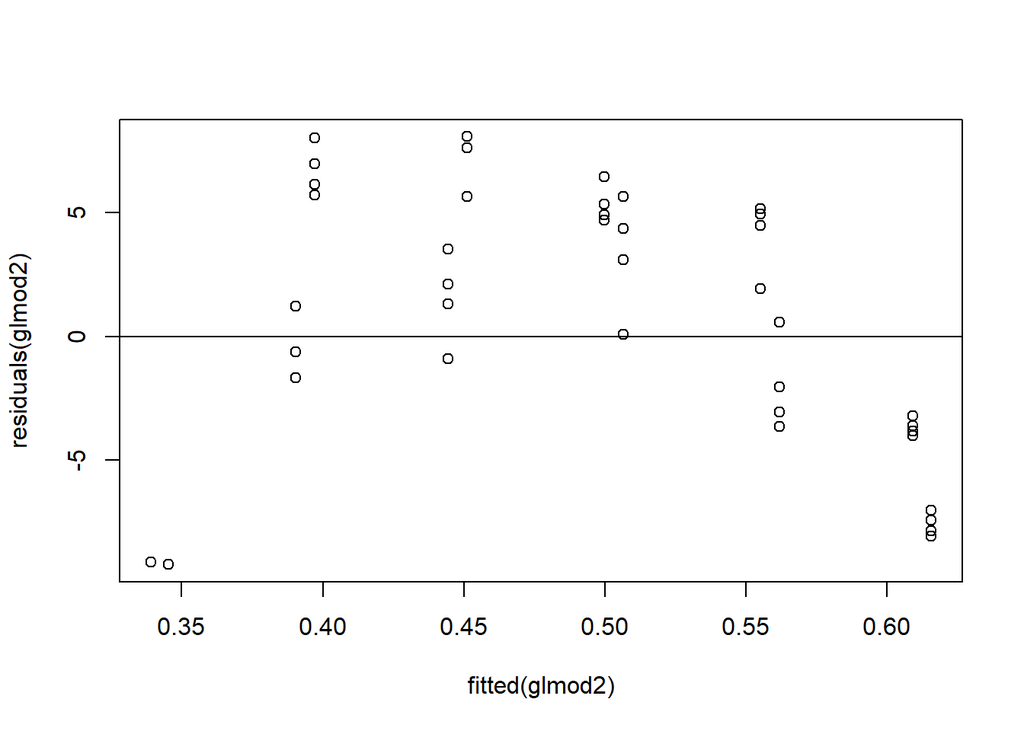

```r
glmfitted <- fitted(glmod2)

plot(residuals(glmod2) ~ fitted(glmod2))
abline(h=0)
```

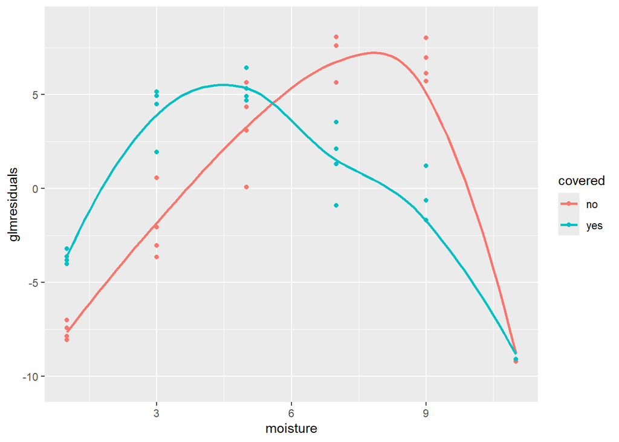

```r
glmresiduals <- residuals(glmod2)

df_new <- df[-47,]

df_new %>% ggplot(aes(x = moisture, y = glmresiduals, color = covered)) +
  geom_point() +
  geom_smooth(fill=NA)
```

8. There appear to be some influential points located at the bottom right of the plot. This seems to indicate some problems with the model.

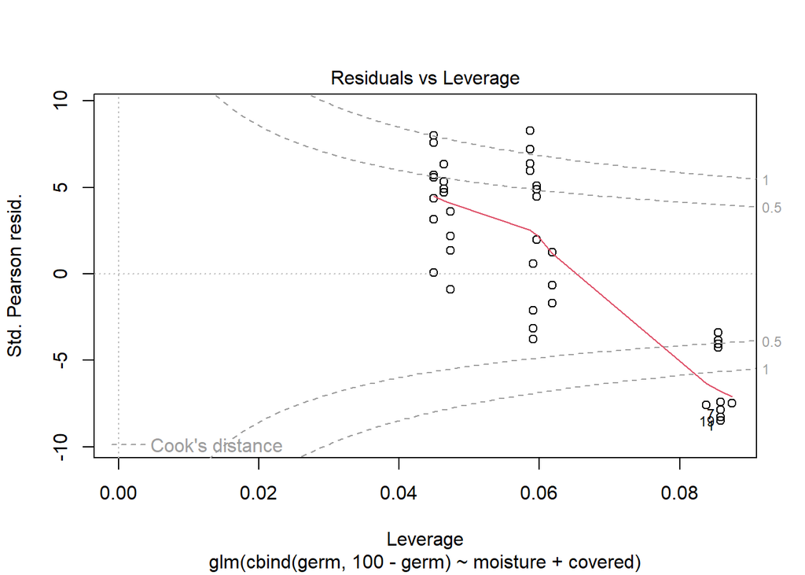

```r
plot(glmod2, which = 5)
```